# CART Model Diamonds Data

Selçuk Açıkalın

24 Ara 2020

Price Estimation Model on Diamonds Dataset

# A Glance at the Data

## Structure

Dataframe consists of both numeric and categorical variables

```r
str(diamonds)
```

```
## tibble [53,940 x 10] (S3: tbl_df/tbl/data.frame)
##  $ carat  : num [1:53940] 0.23 0.21 0.23 0.29 0.31 0.24 0.24 0.26 0.22 0.23 ...
##  $ cut    : Ord.factor w/ 5 levels "Fair"<"Good"<..: 5 4 2 4 2 3 3 3 1 3 ...
##  $ color  : Ord.factor w/ 7 levels "D"<"E"<"F"<"G"<..: 2 2 2 6 7 7 6 5 2 5 ...
##  $ clarity: Ord.factor w/ 8 levels "I1"<"SI2"<"SI1"<..: 2 3 5 4 2 6 7 3 4 5 ...
##  $ depth  : num [1:53940] 61.5 59.8 56.9 62.4 63.3 62.8 62.3 61.9 65.1 59.4 ...
##  $ table  : num [1:53940] 55 61 65 58 58 57 57 55 61 61 ...
##  $ price  : int [1:53940] 326 326 327 334 335 336 336 337 337 338 ...
##  $ x      : num [1:53940] 3.95 3.89 4.05 4.2 4.34 3.94 3.95 4.07 3.87 4 ...
##  $ y      : num [1:53940] 3.98 3.84 4.07 4.23 4.35 3.96 3.98 4.11 3.78 4.05 ...
##  $ z      : num [1:53940] 2.43 2.31 2.31 2.63 2.75 2.48 2.47 2.53 2.49 2.39 ...
```

## Head

```r
head(diamonds)
```

```
## # A tibble: 6 x 10
##   carat cut       color clarity depth table price     x     y     z
##   <dbl> <ord>     <ord> <ord>   <dbl> <dbl> <int> <dbl> <dbl> <dbl>
## 1 0.23  Ideal     E     SI2      61.5    55   326  3.95  3.98  2.43
## 2 0.21  Premium   E     SI1      59.8    61   326  3.89  3.84  2.31
## 3 0.23  Good      E     VS1      56.9    65   327  4.05  4.07  2.31
## 4 0.290 Premium   I     VS2      62.4    58   334  4.2   4.23  2.63
## 5 0.31  Good      J     SI2      63.3    58   335  4.34  4.35  2.75
## 6 0.24  Very Good J     VVS2     62.8    57   336  3.94  3.96  2.48
```

# Visual Inspection

## Preparing Data for ggplot

Since price will be response variable in the model first we need to look at if there were any correlation between numeric variables with price. Getting ready a longer dataframe will be used by ggplot

```r
longer_diamonds <- diamonds %>% select(1, 5,6,7,8,9, 10) %>% pivot_longer(-price, names_to = "names", values_to="values")
longer_diamonds
```

```
## # A tibble: 323,640 x 3
##    price names values
##    <int> <chr>  <dbl>
##  1   326 carat   0.23
##  2   326 depth  61.5
##  3   326 table  55
##  4   326 x       3.95
##  5   326 y       3.98
##  6   326 z       2.43
##  7   326 carat   0.21
##  8   326 depth  59.8
##  9   326 table  61
## 10   326 x       3.89
## # ... with 323,630 more rows
```

## Correlation Detection by Visual Inspection

By Visual inspection it looks like carat, x, y and z variables have strong correlation with price

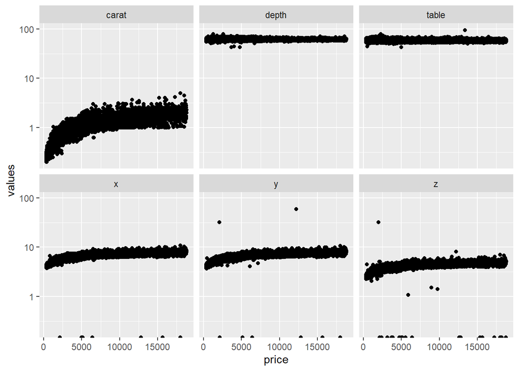

```r
ggplot(longer_diamonds, aes(x=price, y= values)) +
  geom_point() +
  facet_wrap(~ names) +
  scale_y_log10()
```

## Examining Correlation with cor() Function

After cor() function results we could drop depth and table variables for the model since they do not have strong correlation

```r
cor(diamonds$price, diamonds$carat)
```

```
## [1] 0.9215913
```

```r
cor(diamonds$price, diamonds$depth)
```

```
## [1] -0.0106474
```

```r
cor(diamonds$price, diamonds$table)
```

```
## [1] 0.1271339
```

```r
cor(diamonds$price, diamonds$x)
```

```
## [1] 0.8844352
```

```r
cor(diamonds$price, diamonds$y)
```

```
## [1] 0.8654209
```

```r
cor(diamonds$price, diamonds$z)
```

```
## [1] 0.8612494
```

# Properties of New Dataframe w/o depth and table

```r
diamonds_new <- diamonds %>% select(7, 2, 3, 4, 1, 8, 9, 10)
str(diamonds_new)
```

```
## tibble [53,940 x 8] (S3: tbl_df/tbl/data.frame)
##  $ price  : int [1:53940] 326 326 327 334 335 336 336 337 337 338 ...
##  $ cut    : Ord.factor w/ 5 levels "Fair"<"Good"<..: 5 4 2 4 2 3 3 3 1 3 ...
##  $ color  : Ord.factor w/ 7 levels "D"<"E"<"F"<"G"<..: 2 2 2 6 7 7 6 5 2 5 ...
##  $ clarity: Ord.factor w/ 8 levels "I1"<"SI2"<"SI1"<..: 2 3 5 4 2 6 7 3 4 5 ...
##  $ carat  : num [1:53940] 0.23 0.21 0.23 0.29 0.31 0.24 0.24 0.26 0.22 0.23 ...
##  $ x      : num [1:53940] 3.95 3.89 4.05 4.2 4.34 3.94 3.95 4.07 3.87 4 ...
##  $ y      : num [1:53940] 3.98 3.84 4.07 4.23 4.35 3.96 3.98 4.11 3.78 4.05 ...
##  $ z      : num [1:53940] 2.43 2.31 2.31 2.63 2.75 2.48 2.47 2.53 2.49 2.39 ...
```

```r
head(diamonds_new)
```

```
## # A tibble: 6 x 8
##   price cut       color clarity carat     x     y     z
##   <int> <ord>     <ord> <ord>   <dbl> <dbl> <dbl> <dbl>
## 1   326 Ideal     E     SI2     0.23   3.95  3.98  2.43
## 2   326 Premium   E     SI1     0.21   3.89  3.84  2.31
## 3   327 Good      E     VS1     0.23   4.05  4.07  2.31
## 4   334 Premium   I     VS2     0.290  4.2   4.23  2.63
## 5   335 Good      J     SI2     0.31   4.34  4.35  2.75
## 6   336 Very Good J     VVS2    0.24   3.94  3.96  2.48
```

# Model Preparation - Splitting Dataset

We need two sets of data for both training and test.

## Total Rownumber

To do that first we need to know the total row number of diamonds dataframe

```r
n <- nrow(diamonds_new)
```

## Definition of n_train.

Split will be conducted with ratios = %80

```r
n_train <- round(0.80 * n)
```

## Definition of Randomness

For reproducability of whole process

```r
set.seed(87)
```

## Train_Indices

```r
train_indices <- sample(1:n, n_train)
```

## Definitions of Sets

### Training Set

Which is a subset contains the diamonds indices equal to train indices. We will use this data frame to train the model.

```r
diamonds_train <- diamonds_new[train_indices, ]
```

### Test Set

which is a subset contains the diamonds indices not equal to train indices. We will use this data frame to test the model.

```r
diamonds_test <- diamonds_new[-train_indices, ]
```

# Model

## Setting the Model

```r
diamonds_model <- rpart(price ~ ., data = diamonds_train)
```

## Summary of Model

```r
summary(diamonds_model)
```

```
## Call:
## rpart(formula = price ~ ., data = diamonds_train)
##   n= 43152
##
##           CP nsplit rel error    xerror        xstd
## 1 0.60838568      0 1.0000000 1.0000383 0.009847565
## 2 0.18548941      1 0.3916143 0.3916439 0.004400847
## 3 0.03380623      2 0.2061249 0.2061762 0.002316826
## 4 0.02639393      3 0.1723187 0.1724946 0.002315555
## 5 0.02586428      4 0.1459248 0.1502857 0.002035272
## 6 0.01000000      5 0.1200605 0.1207104 0.001738025
##
## Variable importance
##   carat       y       x       z clarity   color
##      25      24      24      23       3       1
##
## Node number 1: 43152 observations,    complexity param=0.6083857
##   mean=3922.407, MSE=1.577363e+07
##   left son=2 (27894 obs) right son=3 (15258 obs)
##   Primary splits:
##       carat < 0.995 to the left,  improve=0.60838570, (0 missing)
##       y     < 6.325 to the left,  improve=0.60678510, (0 missing)
##       x     < 6.335 to the left,  improve=0.60367980, (0 missing)
##       z     < 3.935 to the left,  improve=0.59772800, (0 missing)
##       color splits as  LLLLRRR,   improve=0.02114851, (0 missing)
##   Surrogate splits:
##       x       < 6.275 to the left,  agree=0.983, adj=0.953, (0 split)
##       y       < 6.265 to the left,  agree=0.981, adj=0.947, (0 split)
##       z       < 3.895 to the left,  agree=0.977, adj=0.936, (0 split)
##       clarity splits as  RRLLLLLL,  agree=0.679, adj=0.092, (0 split)
##       color   splits as  LLLLLRR,   agree=0.661, adj=0.041, (0 split)
##
## Node number 2: 27894 observations,    complexity param=0.03380623
##   mean=1631.282, MSE=1239638
##   left son=4 (19550 obs) right son=5 (8344 obs)
##   Primary splits:
##       carat   < 0.605 to the left,  improve=0.66546260, (0 missing)
##       y       < 5.535 to the left,  improve=0.66470980, (0 missing)
##       x       < 5.485 to the left,  improve=0.66228850, (0 missing)
##       z       < 3.375 to the left,  improve=0.66148210, (0 missing)
```

[output cut: 50 more lines]

```
##       carat   < 1.865 to the left,  agree=0.972, adj=0.919, (0 split)
##       z       < 4.825 to the left,  agree=0.952, adj=0.861, (0 split)
##       clarity splits as  RRLLLLLL,  agree=0.680, adj=0.080, (0 split)
##
## Node number 12: 7885 observations
##   mean=5391.396, MSE=2047998
##
## Node number 13: 2454 observations
##   mean=8489.668, MSE=5842194
##
## Node number 14: 3209 observations
##   mean=10900.35, MSE=8620826
##
## Node number 15: 1710 observations
##   mean=14872.92, MSE=7019639
```

## Tree View of Model

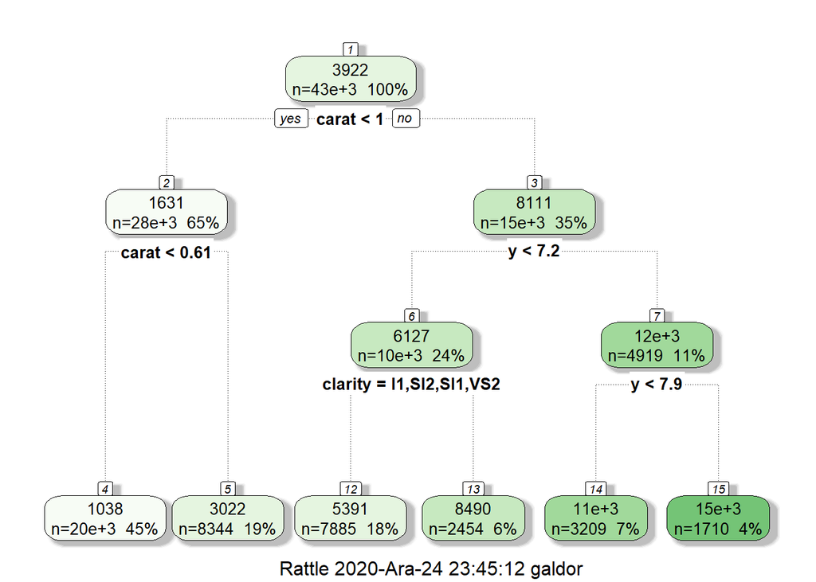

```r
fancyRpartPlot(diamonds_model)
```

## Details of Model

```r
printcp(diamonds_model)
```

```
##
## Regression tree:
## rpart(formula = price ~ ., data = diamonds_train)
##
## Variables actually used in tree construction:
## [1] carat   clarity y
##
## Root node error: 6.8066e+11/43152 = 15773633
##
## n= 43152
##
##         CP nsplit rel error  xerror      xstd
## 1 0.608386      0   1.00000 1.00004 0.0098476
## 2 0.185489      1   0.39161 0.39164 0.0044008
## 3 0.033806      2   0.20612 0.20618 0.0023168
## 4 0.026394      3   0.17232 0.17249 0.0023156
## 5 0.025864      4   0.14592 0.15029 0.0020353
## 6 0.010000      5   0.12006 0.12071 0.0017380
```

## Plot View

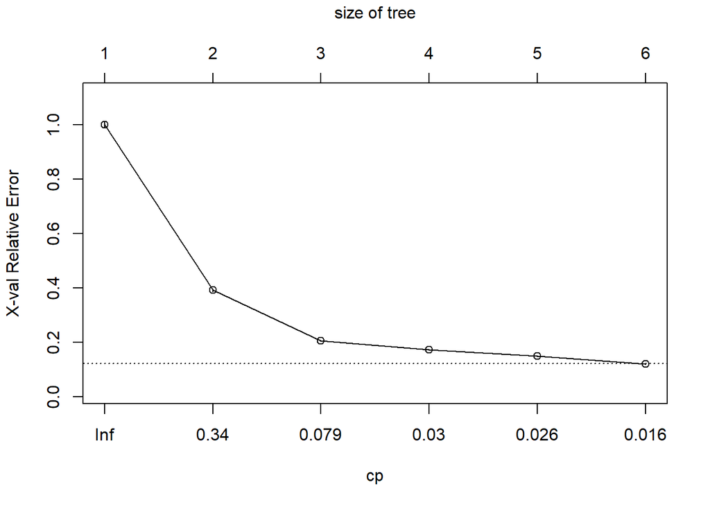

```r
plotcp(diamonds_model)
```

# Prediction

## Prediction values from Model

```r
prediction <- predict(diamonds_model, diamonds_test)

head(prediction,50)
```

```
##        1        2        3        4        5        6        7        8
## 1037.916 1037.916 1037.916 1037.916 1037.916 1037.916 1037.916 1037.916
##        9       10       11       12       13       14       15       16
## 1037.916 1037.916 1037.916 1037.916 1037.916 1037.916 1037.916 1037.916
##       17       18       19       20       21       22       23       24
## 1037.916 1037.916 3021.541 3021.541 3021.541 3021.541 3021.541 3021.541
##       25       26       27       28       29       30       31       32
## 3021.541 3021.541 3021.541 3021.541 3021.541 3021.541 3021.541 3021.541
##       33       34       35       36       37       38       39       40
## 3021.541 3021.541 3021.541 3021.541 1037.916 1037.916 3021.541 3021.541
##       41       42       43       44       45       46       47       48
## 3021.541 3021.541 3021.541 3021.541 3021.541 1037.916 1037.916 3021.541
##       49       50
## 1037.916 3021.541
```

## Pruning the Tree for Optimal Decision Tree

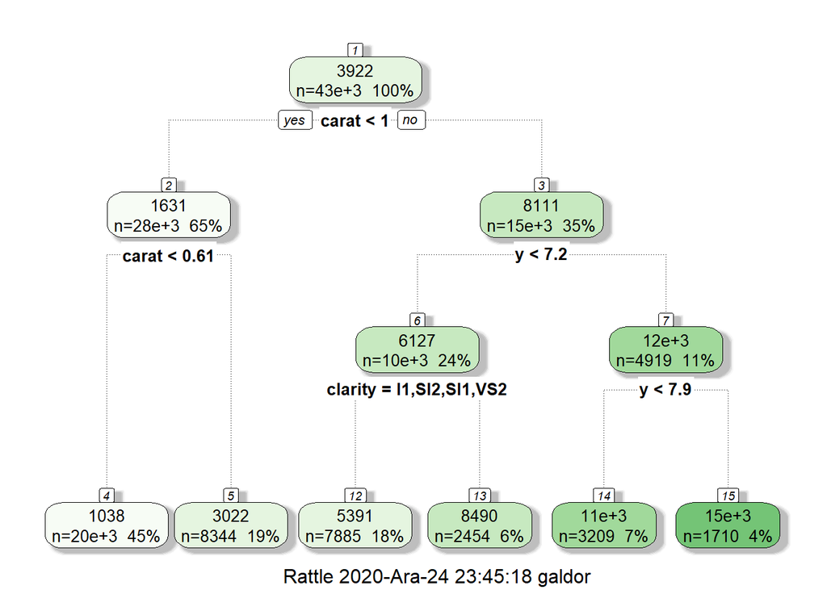

```r
prune_diamonds_model <- prune(diamonds_model,
                cp=diamonds_model$cptable[which.min(diamonds_model$cptable[,"xerror"]),"CP"])

fancyRpartPlot(prune_diamonds_model)
```

## New Prediction with Pruned Model

```r
prediction_11 <- predict(prune_diamonds_model, newdata = diamonds_test)
```

# RESULT: Looking for Correlation of Pruned Model

Strong correlation coefficient

```r
cor(diamonds_test$price, prediction_11)^2
```

```
## [1] 0.8804278
```

# EXTRA: Additional Version of Model

## Turning categorical variables into binary variables

```r
diamonds_new_2 <- mutate(diamonds_new,
                         clarity.I1=ifelse(clarity=='I1',1,0),
                         clarity.SI2=ifelse(clarity=='SI2',1,0),
                         clarity.SI1=ifelse(clarity=='SI1',1,0),
                         clarity.VS2=ifelse(clarity=='VS2',1,0),
                         clarity.VS1=ifelse(clarity=='VS1',1,0),
                         clarity.VVS2=ifelse(clarity=='VVS2',1,0),
                         clarity.VVS1=ifelse(clarity=='VVS1',1,0),
                         clarity.IF=ifelse(clarity=='IF',1,0),
                         color.J=ifelse(color=='J',1,0),
                         color.I=ifelse(color=='I',1,0),
                         color.H=ifelse(color=='H',1,0),
                         color.G=ifelse(color=='G',1,0),
                         color.F=ifelse(color=='F',1,0),
                         color.E=ifelse(color=='E',1,0),
                         color.D=ifelse(color=='D',1,0),
                         cut.Fair=ifelse(cut=='Fair',1,0),
                         cut.Good=ifelse(cut=='Good',1,0),
                         cut.VeryGood=ifelse(cut=='Very Good',1,0),
                         cut.Premium=ifelse(cut=='Premium',1,0),
                         cut.Ideal=ifelse(cut=='Ideal',1,0)
                         ) %>% select(-clarity) %>% select(-color) %>% select(-cut)
```

## Same steps before

```r
str(diamonds_new_2)
```

```
## tibble [53,940 x 25] (S3: tbl_df/tbl/data.frame)
##  $ price       : int [1:53940] 326 326 327 334 335 336 336 337 337 338 ...
##  $ carat       : num [1:53940] 0.23 0.21 0.23 0.29 0.31 0.24 0.24 0.26 0.22 0.23 ...
##  $ x           : num [1:53940] 3.95 3.89 4.05 4.2 4.34 3.94 3.95 4.07 3.87 4 ...
##  $ y           : num [1:53940] 3.98 3.84 4.07 4.23 4.35 3.96 3.98 4.11 3.78 4.05 ...
##  $ z           : num [1:53940] 2.43 2.31 2.31 2.63 2.75 2.48 2.47 2.53 2.49 2.39 ...
##  $ clarity.I1  : num [1:53940] 0 0 0 0 0 0 0 0 0 0 ...
##  $ clarity.SI2 : num [1:53940] 1 0 0 0 1 0 0 0 0 0 ...
##  $ clarity.SI1 : num [1:53940] 0 1 0 0 0 0 0 1 0 0 ...
##  $ clarity.VS2 : num [1:53940] 0 0 0 1 0 0 0 0 1 0 ...
##  $ clarity.VS1 : num [1:53940] 0 0 1 0 0 0 0 0 0 1 ...
##  $ clarity.VVS2: num [1:53940] 0 0 0 0 0 1 0 0 0 0 ...
##  $ clarity.VVS1: num [1:53940] 0 0 0 0 0 0 1 0 0 0 ...
##  $ clarity.IF  : num [1:53940] 0 0 0 0 0 0 0 0 0 0 ...
##  $ color.J     : num [1:53940] 0 0 0 0 1 1 0 0 0 0 ...
##  $ color.I     : num [1:53940] 0 0 0 1 0 0 1 0 0 0 ...
##  $ color.H     : num [1:53940] 0 0 0 0 0 0 0 1 0 1 ...
##  $ color.G     : num [1:53940] 0 0 0 0 0 0 0 0 0 0 ...
##  $ color.F     : num [1:53940] 0 0 0 0 0 0 0 0 0 0 ...
##  $ color.E     : num [1:53940] 1 1 1 0 0 0 0 0 1 0 ...
##  $ color.D     : num [1:53940] 0 0 0 0 0 0 0 0 0 0 ...
##  $ cut.Fair    : num [1:53940] 0 0 0 0 0 0 0 0 1 0 ...
##  $ cut.Good    : num [1:53940] 0 0 1 0 1 0 0 0 0 0 ...
##  $ cut.VeryGood: num [1:53940] 0 0 0 0 0 1 1 1 0 1 ...
##  $ cut.Premium : num [1:53940] 0 1 0 1 0 0 0 0 0 0 ...
##  $ cut.Ideal   : num [1:53940] 1 0 0 0 0 0 0 0 0 0 ...
```

```r
head(diamonds_new_2)
```

```
## # A tibble: 6 x 25
##   price carat     x     y     z clarity.I1 clarity.SI2 clarity.SI1 clarity.VS2
##   <int> <dbl> <dbl> <dbl> <dbl>      <dbl>       <dbl>       <dbl>       <dbl>
## 1   326 0.23   3.95  3.98  2.43          0           1           0           0
## 2   326 0.21   3.89  3.84  2.31          0           0           1           0
## 3   327 0.23   4.05  4.07  2.31          0           0           0           0
## 4   334 0.290  4.2   4.23  2.63          0           0           0           1
## 5   335 0.31   4.34  4.35  2.75          0           1           0           0
## 6   336 0.24   3.94  3.96  2.48          0           0           0           0
## # ... with 16 more variables: clarity.VS1 <dbl>, clarity.VVS2 <dbl>,
## #   clarity.VVS1 <dbl>, clarity.IF <dbl>, color.J <dbl>, color.I <dbl>,
## #   color.H <dbl>, color.G <dbl>, color.F <dbl>, color.E <dbl>, color.D <dbl>,
## #   cut.Fair <dbl>, cut.Good <dbl>, cut.VeryGood <dbl>, cut.Premium <dbl>,
## #   cut.Ideal <dbl>
```

```r
n <- nrow(diamonds_new_2)
n_train <- round(0.80 * n)
set.seed(87)
train_indices <- sample(1:n, n_train)

diamonds_train_2 <- diamonds_new_2[train_indices, ]
diamonds_test_2 <- diamonds_new_2[-train_indices, ]

diamonds_model_2 <- rpart(price ~ ., data = diamonds_train_2)

summary(diamonds_model_2)
```

```
## Call:
## rpart(formula = price ~ ., data = diamonds_train_2)
##   n= 43152
##
##           CP nsplit rel error    xerror        xstd
## 1 0.60838568      0 1.0000000 1.0000383 0.009847565
## 2 0.18548941      1 0.3916143 0.3916439 0.004400847
## 3 0.03380623      2 0.2061249 0.2061762 0.002316826
## 4 0.02586428      3 0.1723187 0.1724946 0.002315555
## 5 0.01163139      4 0.1464544 0.1471034 0.002139989
## 6 0.01015340      5 0.1348230 0.1354726 0.002001479
## 7 0.01000000      6 0.1246696 0.1275272 0.001897575
##
## Variable importance
##       carat           y           x           z clarity.SI2     color.J
##          25          24          24          24           2           1
##
## Node number 1: 43152 observations,    complexity param=0.6083857
##   mean=3922.407, MSE=1.577363e+07
##   left son=2 (27894 obs) right son=3 (15258 obs)
##   Primary splits:
##       carat       < 0.995 to the left,  improve=0.60838570, (0 missing)
##       y           < 6.325 to the left,  improve=0.60678510, (0 missing)
##       x           < 6.335 to the left,  improve=0.60367980, (0 missing)
##       z           < 3.935 to the left,  improve=0.59772800, (0 missing)
##       clarity.SI2 < 0.5   to the left,  improve=0.01708196, (0 missing)
##   Surrogate splits:
##       x           < 6.275 to the left,  agree=0.983, adj=0.953, (0 split)
##       y           < 6.265 to the left,  agree=0.981, adj=0.947, (0 split)
##       z           < 3.895 to the left,  agree=0.977, adj=0.936, (0 split)
##       clarity.SI2 < 0.5   to the left,  agree=0.673, adj=0.075, (0 split)
##       color.J     < 0.5   to the left,  agree=0.658, adj=0.032, (0 split)
##
## Node number 2: 27894 observations,    complexity param=0.03380623
##   mean=1631.282, MSE=1239638
##   left son=4 (19550 obs) right son=5 (8344 obs)
##   Primary splits:
##       carat       < 0.605 to the left,  improve=0.665462600, (0 missing)
##       y           < 5.535 to the left,  improve=0.664709800, (0 missing)
##       x           < 5.485 to the left,  improve=0.662288500, (0 missing)
```

[output cut: 70 more lines]

```
##   Surrogate splits:
##       clarity.VS2 < 0.5   to the left,  agree=0.646, adj=0.027, (0 split)
##       x           < 6.155 to the left,  agree=0.637, adj=0.000, (0 split)
##
## Node number 14: 3209 observations
##   mean=10900.35, MSE=8620826
##
## Node number 15: 1710 observations
##   mean=14872.92, MSE=7019639
##
## Node number 26: 2782 observations
##   mean=5387.052, MSE=1236565
##
## Node number 27: 4875 observations
##   mean=7362.364, MSE=5708098
```

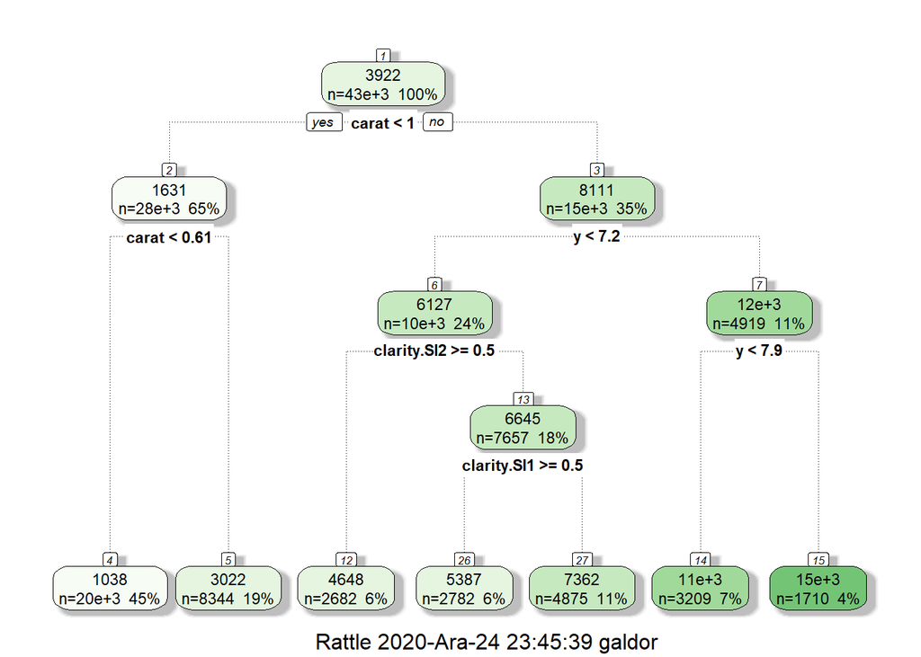

```r
fancyRpartPlot(diamonds_model_2)
```

```r
printcp(diamonds_model_2)
```

```
##
## Regression tree:
## rpart(formula = price ~ ., data = diamonds_train_2)
##
## Variables actually used in tree construction:
## [1] carat       clarity.SI1 clarity.SI2 y
##
## Root node error: 6.8066e+11/43152 = 15773633
##
## n= 43152
##
##         CP nsplit rel error  xerror      xstd
## 1 0.608386      0   1.00000 1.00004 0.0098476
## 2 0.185489      1   0.39161 0.39164 0.0044008
## 3 0.033806      2   0.20612 0.20618 0.0023168
## 4 0.025864      3   0.17232 0.17249 0.0023156
## 5 0.011631      4   0.14645 0.14710 0.0021400
## 6 0.010153      5   0.13482 0.13547 0.0020015
## 7 0.010000      6   0.12467 0.12753 0.0018976
```

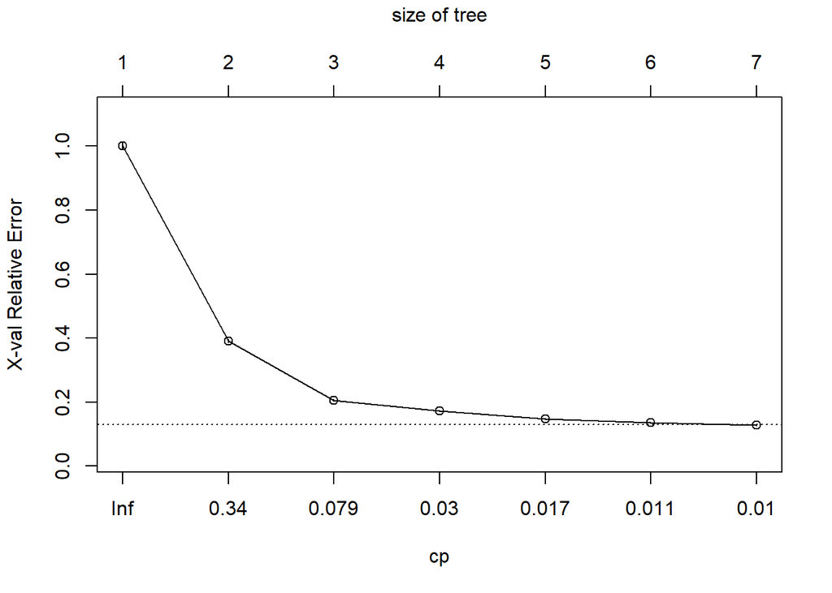

```r
plotcp(diamonds_model_2)
```

```r
prediction_2 <- predict(diamonds_model_2, newdata = diamonds_test_2)
```

```r
head(prediction_2, 50)
```

```
##        1        2        3        4        5        6        7        8
## 1037.916 1037.916 1037.916 1037.916 1037.916 1037.916 1037.916 1037.916
##        9       10       11       12       13       14       15       16
## 1037.916 1037.916 1037.916 1037.916 1037.916 1037.916 1037.916 1037.916
##       17       18       19       20       21       22       23       24
## 1037.916 1037.916 3021.541 3021.541 3021.541 3021.541 3021.541 3021.541
##       25       26       27       28       29       30       31       32
## 3021.541 3021.541 3021.541 3021.541 3021.541 3021.541 3021.541 3021.541
##       33       34       35       36       37       38       39       40
## 3021.541 3021.541 3021.541 3021.541 1037.916 1037.916 3021.541 3021.541
##       41       42       43       44       45       46       47       48
## 3021.541 3021.541 3021.541 3021.541 3021.541 1037.916 1037.916 3021.541
##       49       50
## 1037.916 3021.541
```

References - [Pruning Tree](https://www.edureka.co/blog/implementation-of-decision-tree/) - [Categorical to binary](https://www.kaggle.com/pauldu/diamond-price-prediction-in-r)